# HW 1

Author

Вера Евгеньевна Монина

```r
library(tidyverse)
theme_set(theme_bw())
```

Это [quarto](https://quarto.org/) документ. Чтобы его скомпилировать, можно нажать в RStudio кнопку Render. Вставьте ваше имя в поле автора, а код в соответствующие фрагменты, выделенные знаками `.

## Задание 1.1

Количество сегментов подвергшихся фонологической адаптации в заимствования из русского языка в ахвахском языке можно описать распределением Пуассона с параметром лямбда — 1.98. Посчитайте вероятность, что взятое произвольно слово из словаря будет иметь от 1 до 3 сегментов с фонологической адаптацией.

```r
lambda <- 1.98  # параметр распределения Пуассона
k <- 1:3        # от 1 до 3 сегментов

# Вероятности для каждого cегмента
probabilities <- dpois(x = k, lambda = lambda)
# Суммарная вероятность
total_probability <- sum(probabilities)

print("Вероятности для k = 1, 2, 3:")
```

```
[1] "Вероятности для k = 1, 2, 3:"
```

```r
print(probabilities)
```

```
[1] 0.2733771 0.2706433 0.1786246
```

```r
print(paste("Суммарная вероятность P(1 ≤ X ≤ 3) =", round(total_probability, 4)))
```

```
[1] "Суммарная вероятность P(1 ≤ X ≤ 3) = 0.7226"
```

## Задание 1.2

В работе [Moroz, Verhees 2019] исследовалась вариативность классовой атрибуции в андийском языке и выяснилось, что 9 носителей относят слово *бабочка* к классу *b* и 7 носиителей относят слово к классу *r*. В новой итерации эксперимента 38 носителей отнесли слово *бабочка* к классу *b* и 6 носителей отнесли слово к классу *r*. Визуализируйте функцию правдоподобия и посчитайте какой из вариантов, заданный функцией `seq(0, 1, by = 0.01)`, имеет наибольшее значение функции правдоподобия.

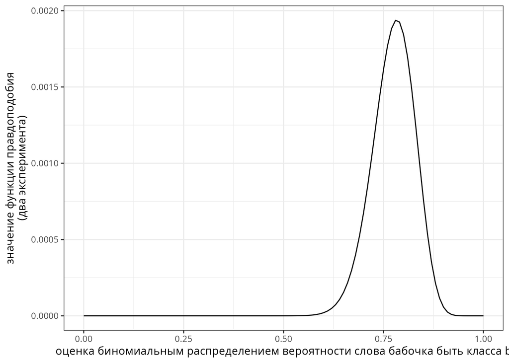

```r
library(tidyverse)
library(ggplot2)

p <- seq(0, 1, by = 0.01)
p_grid <- p
# 1 эксперимент (9 - b, 7 - r)
# беру бин. распределение, потому что у нас только r/b и участники эксп. независимые
x1 <- dbinom(9, 16, p)

p_max_x1 <- p[which.max(x1)]
print(paste("p с максимальным правдоподобием (1 эксп):", p_max_x1))
```

```
[1] "p с максимальным правдоподобием (1 эксп): 0.56"
```

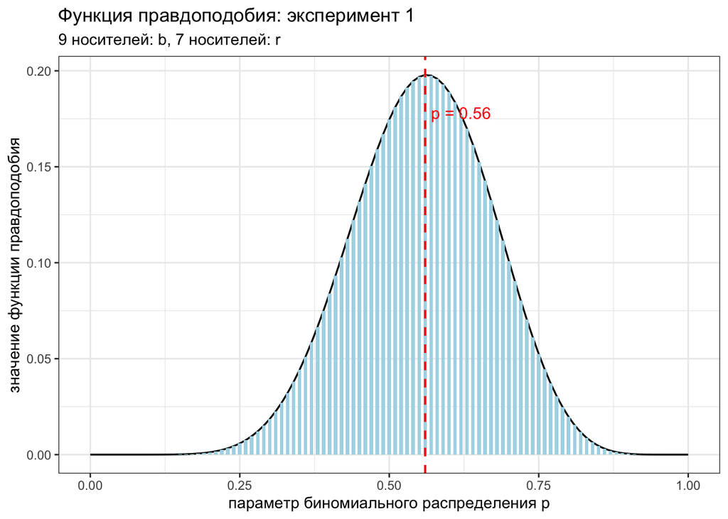

```r
tibble(p = p_grid) |>
   ggplot(aes(p)) +
   stat_function(
      fun = function(p) dbinom(9, 16, p),
      geom = "line",
      color = "black",
      linewidth = 0.6
   )+
   stat_function(
      fun = function(p) dbinom(9, 16, p),
      geom = "col",
      fill = "lightblue",
      width = 0.006
   ) +
   geom_vline(
      xintercept = p_max_x1,
      color = "red",
      linetype = "dashed",
      linewidth = 0.7
   ) +
   annotate(
      "text",
      x = p_max_x1,
      y = max(x1) * 0.9,
      label = paste("p =", p_max_x1),
      color = "red",
      size = 4,
      hjust = -0.1
   ) +
   labs(
      title = "Функция правдоподобия: эксперимент 1",
      subtitle = "9 носителей: b, 7 носителей: r",
      x = "параметр биномиального распределения p",
      y = "значение функции правдоподобия"
   ) +
   theme_bw()
```

```r
# 2 эксперимент (38 - b, 6 - r)
x2 <- dbinom(38, 44, p)

p_max_x2 <- p[which.max(x2)]
print(paste("p с максимальным правдоподобием (2 эксп):", p_max_x2))
```

```
[1] "p с максимальным правдоподобием (2 эксп): 0.86"
```

[figure not shown]

```r
tibble(p = p_grid) |>
   ggplot(aes(p)) +
   stat_function(
      fun = function(p) dbinom(38, 44, p),
      geom = "line",
      color = "black",
      linewidth = 0.6
   ) +
   stat_function(
      fun = function(p) dbinom(38, 44, p),
      geom = "col",
      fill = "lightgreen",
      width = 0.006
   ) +
   geom_vline(
      xintercept = p_max_x2,
      color = "red",
      linetype = "dashed",
      linewidth = 0.7
   ) +
   annotate(
      "text",
      x = p_max_x2,
      y = max(x2) * 0.9,
      label = paste("p =", p_max_x2),
      color = "red",
      size = 4,
      hjust = -0.1
   ) +
   labs(
      title = "Функция правдоподобия: эксперимент 2",
      subtitle = "38 носителей: b, 44 носителей: r",
      x = "параметр биномиального распределения p",
      y = "значение функции правдоподобия"
   ) +
   theme_bw()
```

```r
# Совместная функция правдоподобия
x_joint <- x1 * x2
p_max_joint <- p[which.max(x_joint)]
print(p_max_joint)
```

```
[1] 0.78
```

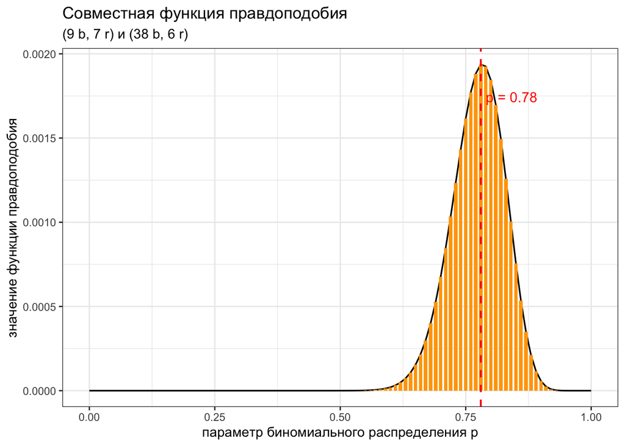

```r
tibble(p = p_grid) |>
   ggplot(aes(p)) +
   stat_function(
      fun = function(p) dbinom(9, 16, p) * dbinom(38, 44, p),
      geom = "line",
      color = "black",
      linewidth = 0.6
   ) +
   stat_function(
      fun = function(p) dbinom(9, 16, p) * dbinom(38, 44, p),
      geom = "col",
      fill = "orange",
      width = 0.007
   ) +
   geom_vline(
      xintercept = p_max_joint,
      color = "red",
      linetype = "dashed",
      linewidth = 0.7
   ) +

   annotate(
      "text",
      x = p_max_joint,
      y = max(x_joint) * 0.9,
      label = paste("p =", p_max_joint),
      color = "red",
      size = 4,
      hjust = -0.1
   ) +
   labs(
      title = "Совместная функция правдоподобия",
      subtitle = "(9 b, 7 r) и (38 b, 6 r)",
      x = "параметр биномиального распределения p",
      y = "значение функции правдоподобия"
   ) +
   theme_bw()
```

## Задание 1.3

В `.csv` файл `data_1.3.csv` записаны данные времени реакции канадцев на некоторые трехсложных английские существительные с ударением на первый слог из работы [Tucker 2021]. Воспользуйтесь методом максимального правдоподобия, чтобы оценить параметры нормального и логнормального распределения, описывающие длительность гласных всех носителей и постройте следующий график.

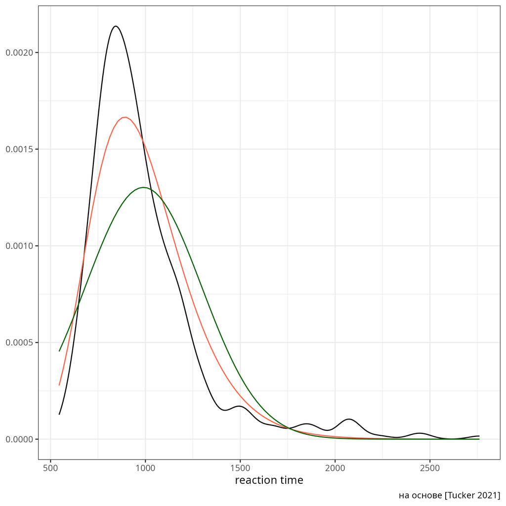

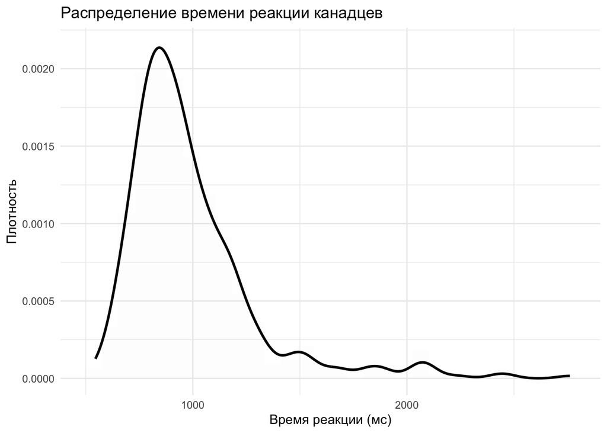

```r
# 3 задание
library(fitdistrplus)
data <- read_csv("/Users/veramonina/Downloads/data_1.3.csv")
ggplot(data, aes(x = RT)) +
   geom_histogram(aes(y = ..density..), bins = 30, alpha = 0.01) +
   geom_density(color = "black", linewidth = 1) +
   labs(title = "Распределение времени реакции канадцев",
      x = "Время реакции (мс)",
      y = "Плотность") +
   theme_minimal()
```

```r
norm_fit <- fitdist(data$RT, distr = "norm", method = "mle")
paste("Параметры нормального распределения:")
```

```
[1] "Параметры нормального распределения:"
```

```r
print(norm_fit$estimate)
```

```
    mean       sd
989.8469 306.3511
```

```r
lnorm_fit <- fitdist(data$RT, distr = "lnorm", method = "mle")
paste("Параметры логнормального распределения:")
```

```
[1] "Параметры логнормального распределения:"
```

```r
print(lnorm_fit$estimate)
```

```
  meanlog     sdlog
6.8602521 0.2596987
```

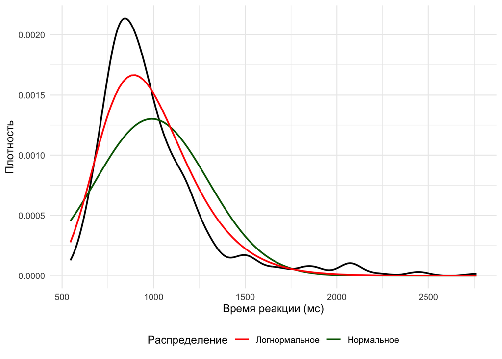

```r
ggplot(data, aes(x = RT)) +
   geom_density(color = "black", linewidth = 0.8) +
   stat_function(fun = dnorm,
      args = list(mean = norm_fit$estimate[1], sd = norm_fit$estimate[2]),
      aes(color = "Нормальное"), linewidth = 0.8) +
   stat_function(fun = dlnorm,
      args = list(meanlog = lnorm_fit$estimate[1], sdlog = lnorm_fit$estimate[2]),
      aes(color = "Логнормальное"), linewidth = 0.8) +
   scale_color_manual(values = c("Нормальное" = "darkgreen",
      "Логнормальное" = "red")) +
   labs(
      x = "Время реакции (мс)",
      y = "Плотность",
      color = "Распределение")+
   theme_minimal() +
   theme(legend.position = "bottom")
```

## Задание 1.4

Место для рефлексии по поводу ответов. Заполняется после того, как присланы ответы на задания до 20.02.2026 23:59. Это оцениваемое задание.